# R Exercises

2020-04-30

The COVID-19 pandemics is a lot of bad things, but it’s also a source of data to play with…

Here we’re gonna use the data gathered by the John’s Hopkins Hospital and published on [GitHub](https://github.com/CSSEGISandData/COVID-19), for [confirmed cases](https://raw.githubusercontent.com/CSSEGISandData/COVID-19/master/csse_covid_19_data/csse_covid_19_time_series/time_series_covid19_confirmed_global.csv) and [deaths](https://raw.githubusercontent.com/CSSEGISandData/COVID-19/master/csse_covid_19_data/csse_covid_19_time_series/time_series_covid19_deaths_global.csv).

In case the links above die at some point, here is a version of these files as of April 21st, 2020:

- confirmed cases
- deaths

In fact, a [quick lookup](https://www.statsandr.com/blog/top-r-resources-on-covid-19-coronavirus/#r-shiny-apps) on the Internet will now return plenty of versions for this data, with even cleaner (tidy) versions, including country population, etc. There are even R packages to get this. The point here is to learn how to read a given dataset, clean it and use it, so we’ll stay with the JHU dataset.

# 1 Data wrangling

# 2 Plotting

- Using `ggplot2`, plot (P1) side by side the number of confirmed cases and deaths vs time in China, Italy, France, Spain and the US.
  - Using `ggrepel`, add the country names as annotation
  - Use a log scale
- Plot (P2) the death ratio per country (averaged over time)
  - is there anything wrong?
- To better see the effect of confinement regulation, it’s probably more interesting to plot the number of new confirmed cases. Plot as a barplot the number of new confirmed cases per day for 2 countries of your choice, and add a vertical line corresponding to the date of application of confinement rules.

# 3 Fitting

- Load the library `broom` ([vignette](https://cran.r-project.org/web/packages/broom/vignettes/broom.html)). `broom` allows tidying the output of fit functions such as `lm()` or `nls()`, taking the text output and making it into a tibble. Example:

```r
library(broom)
library(tidyverse)
library(ggplot2)
theme_set(theme_bw())
# Create fake data
a <- seq(-10,10,1)
d <- tibble(x=rep(a,3),
            y=c(a*runif(1)+runif(length(a)),
                a*runif(1)+1+runif(length(a)),
                a*runif(1)+2+runif(length(a))),
            T=factor(rep(1:3,each=length(a)))
            )
# Fit the data using nls() in a do() loop
d_fit <- d %>% group_by(T) %>%
    do(fit=nls(data=.,
               y~x*A+B,
               start=list(A=1, B=1)))
d_fit
```

```
## Source: local data frame [3 x 2]
## Groups: <by row>
##
## # A tibble: 3 x 2
##   T     fit
## * <fct> <list>
## 1 1     <nls>
## 2 2     <nls>
## 3 3     <nls>
```

```r
d_fit %>% augment(fit)
```

```
## # A tibble: 63 x 5
## # Groups:   T [3]
##    T         x      y .fitted  .resid
##    <fct> <dbl>  <dbl>   <dbl>   <dbl>
##  1 1       -10 -7.32   -7.15  -0.168
##  2 1        -9 -6.01   -6.38   0.373
##  3 1        -8 -5.83   -5.61  -0.217
##  4 1        -7 -4.74   -4.84   0.0950
##  5 1        -6 -3.74   -4.07   0.329
##  6 1        -5 -3.61   -3.30  -0.312
##  7 1        -4 -2.66   -2.52  -0.140
##  8 1        -3 -1.59   -1.75   0.167
##  9 1        -2 -1.23   -0.982 -0.246
## 10 1        -1 -0.377  -0.211 -0.166
## # … with 53 more rows
```

```r
d_fit %>% tidy(fit)
```

```
## # A tibble: 6 x 6
## # Groups:   T [3]
##   T     term  estimate std.error statistic  p.value
##   <fct> <chr>    <dbl>     <dbl>     <dbl>    <dbl>
## 1 1     A        0.771   0.00873      88.3 2.63e-26
## 2 1     B        0.560   0.0529       10.6 2.05e- 9
## 3 2     A        0.930   0.00870     107.  6.95e-28
## 4 2     B        1.57    0.0527       29.7 2.14e-17
## 5 3     A        0.390   0.00985      39.6 1.02e-19
## 6 3     B        2.52    0.0596       42.2 3.00e-20
```

```r
d_fit %>% tidy(fit) %>%
  select(T, term, estimate, std.error) %>%
  pivot_wider(names_from = term,
              values_from = c(estimate,std.error))
```

```
## # A tibble: 3 x 5
## # Groups:   T [3]
##   T     estimate_A estimate_B std.error_A std.error_B
##   <fct>      <dbl>      <dbl>       <dbl>       <dbl>
## 1 1          0.771      0.560     0.00873      0.0529
## 2 2          0.930      1.57      0.00870      0.0527
## 3 3          0.390      2.52      0.00985      0.0596
```

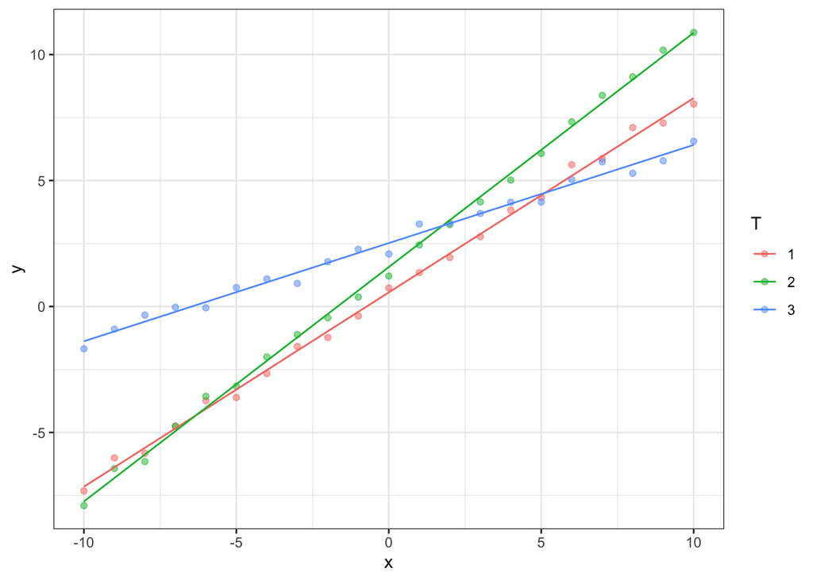

```r
ggplot(data=d, aes(x=x, y=y, col=T))+
    geom_point(alpha=0.5) +
    geom_line(data=d_fit %>% augment(fit),
        aes(x=x,y=.fitted, col=T))
```

Here, by using `do()`, we can apply the fit to each group. The result is a tibble containing the fit result for each group. Then, using `broom`’s function `augment()` and `tidy()`, we respectively get the fitted values and residues, and the fitting parameters.

- Now then, using the same procedure as in the example above, fit the 20 first days of the pandemic by an exponential (confirmed cases), and plot the data for the countries in the first plot (all days), plus the result of the fit. Here is the expected plot:

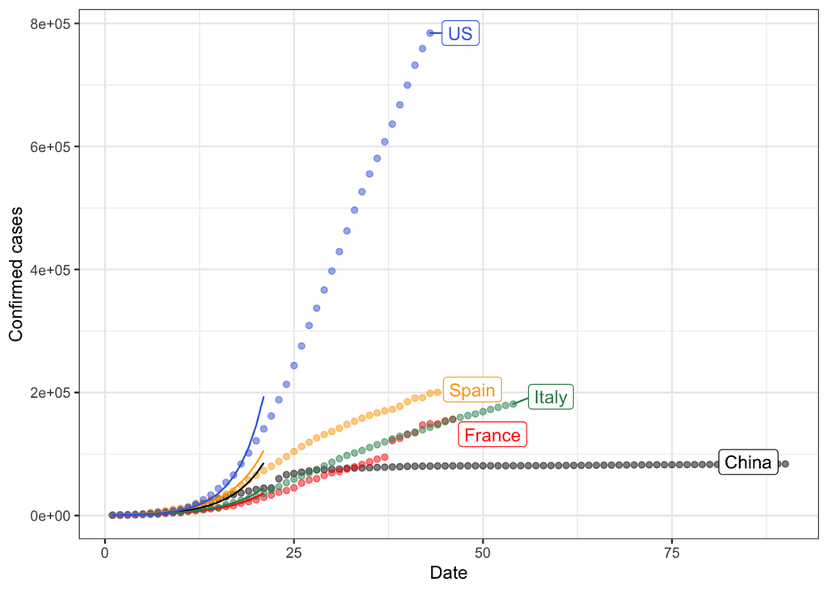